# Week 8

Simranjit

2022-11-10

```r
library(tidyverse)
library(magrittr)
library(psych)
library(caret)
library(gbm)
library(xgboost)
library(data.table)
library(ggforce)
```

```r
set.seed(45)
dataset <- readRDS("C:/Users/L.Singh/OneDrive/Bureaublad/simran/data/data/train_disease.RDS")
```

1. Get an impression of the data by looking at the structure of the data and creating some descriptive statistics.

```r
head(dataset)
```

```
## # A tibble: 6 × 11
##     Age Gender Total_B…¹ Direc…² Alkal…³ Alami…⁴ Aspar…⁵ Total…⁶ Albumin Ratio…⁷
##   <dbl> <fct>      <dbl>   <dbl>   <dbl>   <dbl>   <dbl>   <dbl>   <dbl>   <dbl>
## 1    58 Female       1.7     0.8    1896      61      83     8       3.9    0.95
## 2    56 Male         1       0.3     195      22      28     5.8     2.6    0.8
## 3    35 Male         2       1.1     226      33     135     6       2.7    0.8
## 4    51 Female       0.9     0.2     280      21      30     6.7     3.2    0.8
## 5    21 Male        18.5     9.5     380     390     500     8.2     4.1    1
## 6    60 Male         3.2     1.8     750      79     145     7.8     3.2    0.69
## # … with 1 more variable: Disease <fct>, and abbreviated variable names
## #   ¹Total_Bilirubin, ²Direct_Bilirubin, ³Alkaline_Phosphotase,
## #   ⁴Alamine_Aminotransferase, ⁵Aspartate_Aminotransferase, ⁶Total_Protiens,
## #   ⁷Ratio_Albumin_Globulin
```

```r
tail(dataset)
```

```
## # A tibble: 6 × 11
##     Age Gender Total_B…¹ Direc…² Alkal…³ Alami…⁴ Aspar…⁵ Total…⁶ Albumin Ratio…⁷
##   <dbl> <fct>      <dbl>   <dbl>   <dbl>   <dbl>   <dbl>   <dbl>   <dbl>   <dbl>
## 1    45 Male         0.8     0.2     140      24      20     6.3     3.2    1
## 2    48 Female       1.4     0.8     621     110     176     7.2     3.9    1.1
## 3    17 Male         0.9     0.3     202      22      19     7.4     4.1    1.2
## 4    38 Male         0.8     0.2     247      55      92     7.4     4.3    1.38
## 5    42 Male        16.4     8.9     245      56      87     5.4     2      0.5
## 6    37 Male         1.3     0.4     195      41      38     5.3     2.1    0.6
## # … with 1 more variable: Disease <fct>, and abbreviated variable names
## #   ¹Total_Bilirubin, ²Direct_Bilirubin, ³Alkaline_Phosphotase,
## #   ⁴Alamine_Aminotransferase, ⁵Aspartate_Aminotransferase, ⁶Total_Protiens,
## #   ⁷Ratio_Albumin_Globulin
```

```r
dataset %>%
  select(-c(Gender, Disease)) %>%
  describeBy(dataset$Disease, fast = TRUE)
```

```
##
##  Descriptive statistics by group
## group: Healthy
##                            vars   n   mean     sd  min    max  range    se
## Age                           1 360  45.81  15.60 10.0   90.0   80.0  0.82
## Total_Bilirubin               2 360   4.05   7.15  0.4   75.0   74.6  0.38
## Direct_Bilirubin              3 360   1.86   3.16  0.1   19.7   19.6  0.17
## Alkaline_Phosphotase          4 360 309.47 250.37 63.0 2110.0 2047.0 13.20
## Alamine_Aminotransferase      5 360  97.19 200.17 12.0 1680.0 1668.0 10.55
## Aspartate_Aminotransferase    6 360 133.66 324.59 11.0 4929.0 4918.0 17.11
## Total_Protiens                7 360   6.47   1.11  2.7    9.6    6.9  0.06
## Albumin                       8 360   3.07   0.80  0.9    5.5    4.6  0.04
## Ratio_Albumin_Globulin        9 360   0.92   0.32  0.3    2.8    2.5  0.02
## ------------------------------------------------------------
## group: Disease
##                            vars   n   mean     sd   min    max   range    se
## Age                           1 140  41.51  16.98  4.00   85.0   81.00  1.43
## Total_Bilirubin               2 140   1.14   1.01  0.50    7.3    6.80  0.09
## Direct_Bilirubin              3 140   0.40   0.53  0.10    3.6    3.50  0.04
## Alkaline_Phosphotase          4 140 220.56 149.76 90.00 1580.0 1490.00 12.66
## Alamine_Aminotransferase      5 140  33.31  24.50 10.00  181.0  171.00  2.07
## Aspartate_Aminotransferase    6 140  39.79  34.79 10.00  285.0  275.00  2.94
## Total_Protiens                7 140   6.53   1.07  3.70    9.2    5.50  0.09
## Albumin                       8 140   3.34   0.80  1.40    5.0    3.60  0.07
## Ratio_Albumin_Globulin        9 140   1.04   0.30  0.37    1.9    1.53  0.03
```

2.To further explore the data we work with, create some interesting data visualizations that show whether there are interesting patterns in the data.

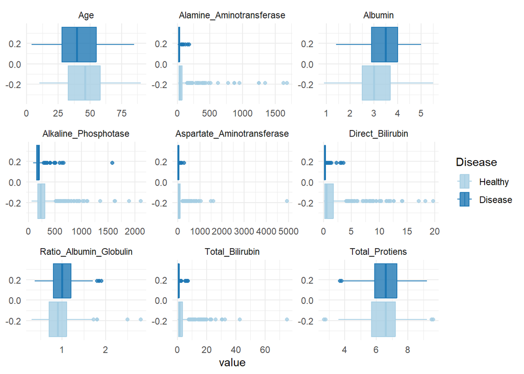

```r
dataset %>%
  select(-Gender) %>%
  pivot_longer(where(is.numeric)) %>%
  ggplot(aes(x = value, col = Disease, fill = Disease)) +
  geom_boxplot(alpha = 0.8) +
  facet_wrap(~name, scales = "free") +
  scale_color_brewer(palette = "Paired") +
  scale_fill_brewer(palette = "Paired") +
  theme_minimal()
```

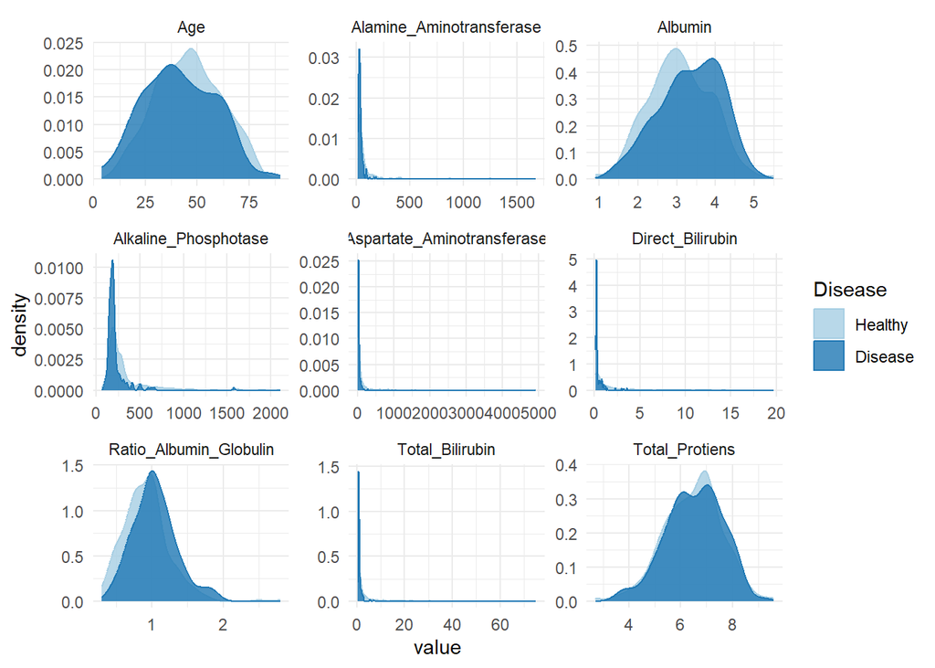

```r
dataset %>%
  select(-Gender) %>%
  pivot_longer(where(is.numeric)) %>%
  ggplot(aes(x = value, col = Disease, fill = Disease)) +
  geom_density(alpha = 0.8) +
  facet_wrap(~name, scales = "free") +
  scale_color_brewer(palette = "Paired") +
  scale_fill_brewer(palette = "Paired") +
  theme_minimal()
```

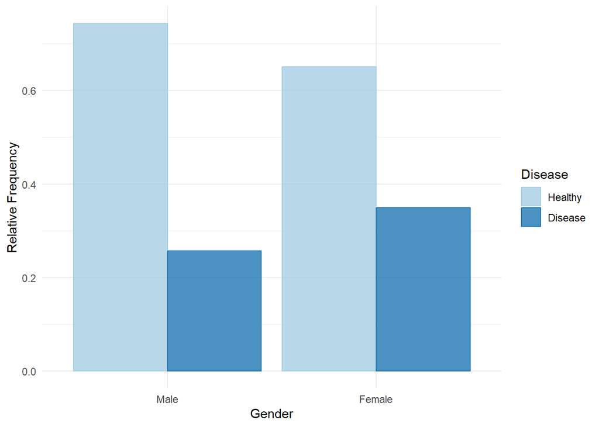

```r
prop.table(table(dataset$Gender, dataset$Disease), margin = 1) %>%
  as.data.frame %>%
  select(Gender = Var1, Disease = Var2, `Relative Frequency` = Freq) %>%
  ggplot(aes(y = `Relative Frequency`, x = Gender, col = Disease, fill = Disease)) +
  geom_histogram(alpha = 0.8, stat = "identity", position = "dodge") +
  scale_fill_brewer(palette = "Paired") +
  scale_color_brewer(palette = "Paired") +
  theme_minimal()
```

##3. Reflect on the difference between bagging, random forests, and boosting.

##Bagging

The process of using bootstrapped samples with replacement and applying a model on each of them and then average out the results to avoid high variance is called bagging. ##Random Forest while building each tree in random forest, not all the features are considered at each split.

In bagging, we take all the features at each split unlike discounting them in random forests. ##Boosting Boosting is a sequential process. Boosting involves combining a large number of decision trees.

Boosting learns the patterns in the data from weak learners to finally develop a strong model.

There is always an ambiguity in deciding when to use bagging or boosting in the data sets that we will encounter. Bagging will give best results when it is in concern with over fitting or high variance and Boosting will perform well with models that have high errors and reduces them as it enhances and reduces the risk of errors by adjusting weights to weak learners. B

4. Apply bagging to the training data, to predict the outcome Disease, using the caret library.

```r
cvcontrol <- trainControl(method = "repeatedcv",
                          number = 10,
                          allowParallel = TRUE)

bag_train <- train(Disease ~ .,
                   data = dataset,
                   method = 'treebag',
                   trControl = cvcontrol,
                   importance = TRUE)
```

5. Interpret the variable importance measure using the varImp function on the trained model object.

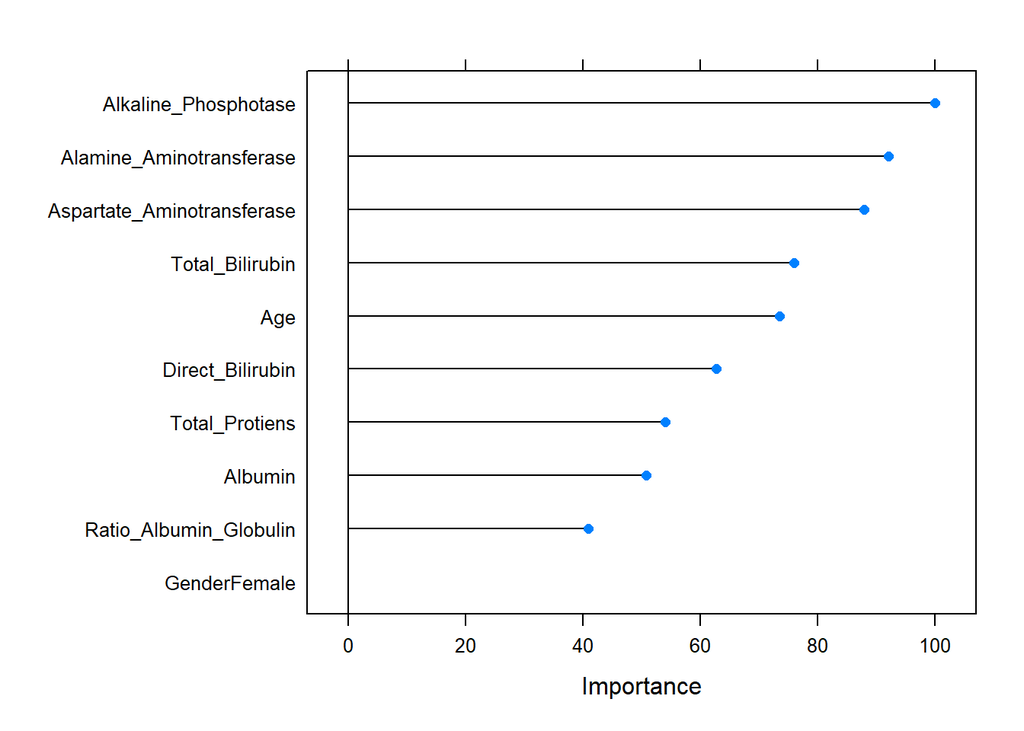

```r
bag_train %>%
  varImp %>%
  plot
```

6. Create training set predictions based on the bagged model, and use the confusionMatrix() function from the caret package to assess it’s performance.`

```r
confusionMatrix(predict(bag_train, type = "raw"),
                dataset$Disease)
```

```
## Confusion Matrix and Statistics
##
##           Reference
## Prediction Healthy Disease
##    Healthy     360       0
##    Disease       0     140
##
##                Accuracy : 1
##                  95% CI : (0.9926, 1)
##     No Information Rate : 0.72
##     P-Value [Acc > NIR] : < 2.2e-16
##
##                   Kappa : 1
##
##  Mcnemar's Test P-Value : NA
##
##             Sensitivity : 1.00
##             Specificity : 1.00
##          Pos Pred Value : 1.00
##          Neg Pred Value : 1.00
##              Prevalence : 0.72
##          Detection Rate : 0.72
##    Detection Prevalence : 0.72
##       Balanced Accuracy : 1.00
##
##        'Positive' Class : Healthy
##
```

7. Output and difference between both approaches

```r
bag_train
```

```
## Bagged CART
##
## 500 samples
##  10 predictor
##   2 classes: 'Healthy', 'Disease'
##
## No pre-processing
## Resampling: Cross-Validated (10 fold, repeated 1 times)
## Summary of sample sizes: 450, 450, 450, 450, 450, 450, ...
## Resampling results:
##
##   Accuracy  Kappa
##   0.678     0.1311671
```

8. Fit a random forest to the training data to predict the outcome Disease, using the caret library.

```r
rf_train <- train(Disease ~ .,
                  data = dataset,
                  method = 'rf',
                  trControl = cvcontrol,
                  importance = TRUE)
```

9.Again, interpret the variable importance measure using the varImp function on the trained model object. Do you draw the same conclusions as under the bagged model?

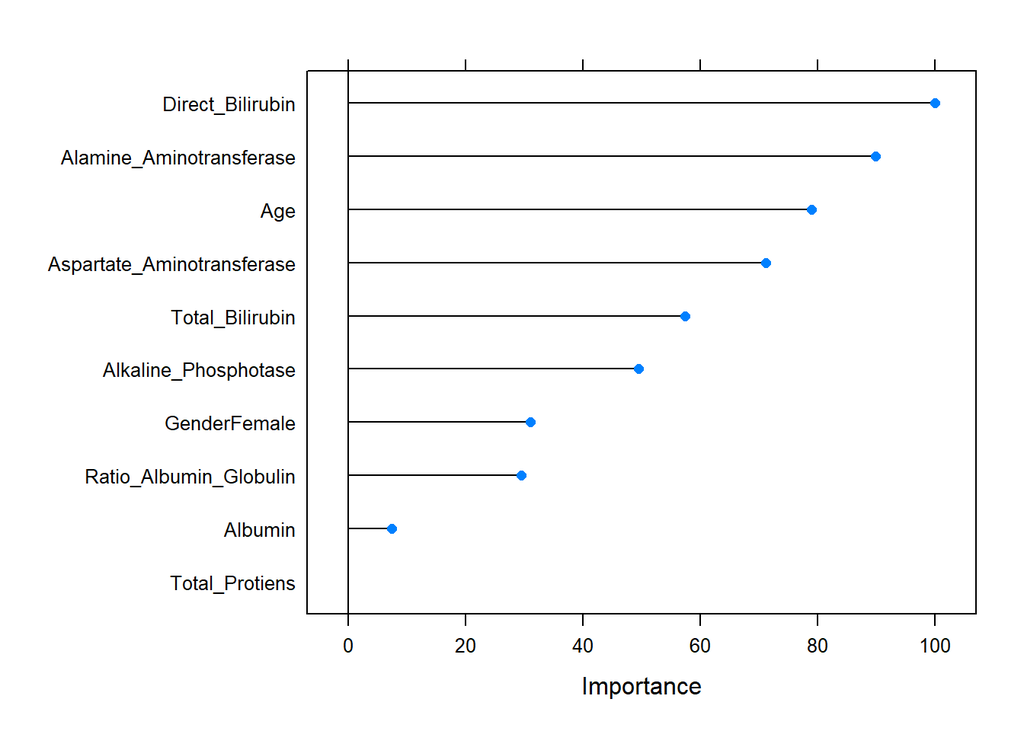

```r
rf_train %>%
  varImp %>%
  plot
```

10.Output from the random forest.

```r
rf_train
```

```
## Random Forest
##
## 500 samples
##  10 predictor
##   2 classes: 'Healthy', 'Disease'
##
## No pre-processing
## Resampling: Cross-Validated (10 fold, repeated 1 times)
## Summary of sample sizes: 450, 450, 450, 450, 450, 450, ...
## Resampling results across tuning parameters:
##
##   mtry  Accuracy  Kappa
##    2    0.688     0.1179249
##    6    0.692     0.1649948
##   10    0.692     0.1661658
##
## Accuracy was used to select the optimal model using the largest value.
## The final value used for the model was mtry = 6.
```

11.Now, fit a boosting model using the caret library to predict disease status.`

```r
gbm_train <- train(Disease ~ .,
                   data = dataset,
                   method = "gbm",
                   verbose = F,
                   trControl = cvcontrol)
```

12. Again, interpret the variable importance measure. You will have to call for summary() on the model object you just created. Compare the output to the previously obtained variable importance measures.

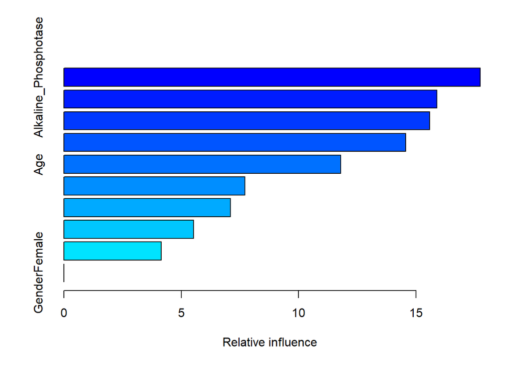

```
##                                                   var   rel.inf
## Alkaline_Phosphotase             Alkaline_Phosphotase 17.730854
## Alamine_Aminotransferase     Alamine_Aminotransferase 15.889482
## Direct_Bilirubin                     Direct_Bilirubin 15.572492
## Aspartate_Aminotransferase Aspartate_Aminotransferase 14.558833
## Age                                               Age 11.785507
## Ratio_Albumin_Globulin         Ratio_Albumin_Globulin  7.703000
## Total_Bilirubin                       Total_Bilirubin  7.091950
## Albumin                                       Albumin  5.519668
## Total_Protiens                         Total_Protiens  4.148215
## GenderFemale                             GenderFemale  0.000000
```

```r
summary(gbm_train)
```

13.Output the model output from our gradient boosting procedure. Are we doing better than with the bagged and random forest model?

```r
gbm_train
```

```
## Stochastic Gradient Boosting
##
## 500 samples
##  10 predictor
##   2 classes: 'Healthy', 'Disease'
##
## No pre-processing
## Resampling: Cross-Validated (10 fold, repeated 1 times)
## Summary of sample sizes: 450, 450, 450, 450, 450, 450, ...
## Resampling results across tuning parameters:
##
##   interaction.depth  n.trees  Accuracy  Kappa
##   1                   50      0.712     0.09569625
##   1                  100      0.712     0.16033979
##   1                  150      0.702     0.15411887
##   2                   50      0.694     0.09651620
##   2                  100      0.684     0.12744126
##   2                  150      0.676     0.12138676
##   3                   50      0.688     0.12456452
##   3                  100      0.698     0.15242249
##   3                  150      0.694     0.13992459
##
## Tuning parameter 'shrinkage' was held constant at a value of 0.1
##
## Tuning parameter 'n.minobsinnode' was held constant at a value of 10
## Accuracy was used to select the optimal model using the largest value.
## The final values used for the model were n.trees = 50, interaction.depth =
##  1, shrinkage = 0.1 and n.minobsinnode = 10.
```

```r
library(devtools)
source_url("https://github.com/pablo14/shap-values/blob/master/shap.R?raw=TRUE")
```

```
## ℹ SHA-1 hash of file is "602645f005640081bb3b11b47eab27b730d74dc8"
```

15. Specify your model as follows, and use it to create predictions on the training data.

```r
train_x <- model.matrix(Disease ~ ., dataset)[,-1]
train_y <- as.numeric(dataset$Disease) - 1
xgboost_train <- xgboost(data = train_x,
                         label = train_y,
                         max.depth = 10,
                         eta = 1,
                         nthread = 4,
                         nrounds = 4,
                         objective = "binary:logistic",
                         verbose = 2)
pred <- tibble(Disease = predict(xgboost_train, newdata = train_x)) %>%
  mutate(Disease = factor(ifelse(Disease < 0.5, 1, 2),
                          labels = c("Healthy", "Disease")))

table(pred$Disease, dataset$Disease)
```

```
##
##           Healthy Disease
##   Healthy     357       6
##   Disease       3     134
```

16. First, calculate the SHAP rank scores for all variables in the data, and create a variable importance plot using these values. Interpret the plot.

```r
shap_results <- shap.score.rank(xgboost_train,
                                X_train = train_x,
                                shap_approx = F)
```

```
## make SHAP score by decreasing order
```

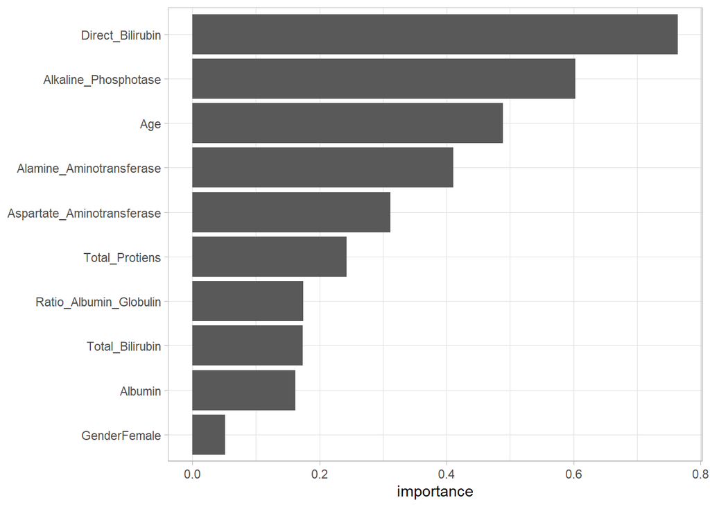

```r
var_importance(shap_results)
```

17. Plot the SHAP values for every individual for every feature and interpret them.

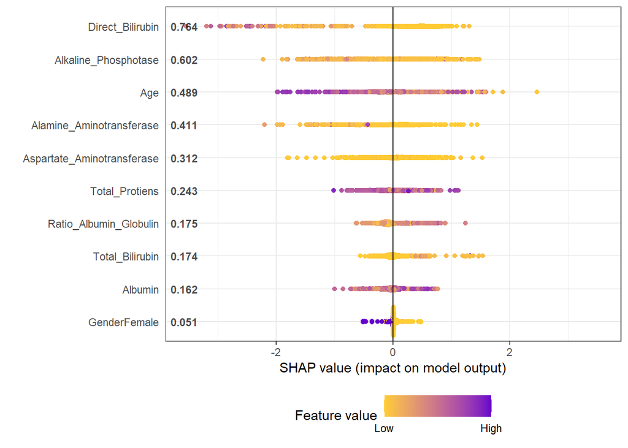

```r
shap_long <- shap.prep(shap = shap_results,
                       X_train = train_x)

plot.shap.summary(shap_long)
```